# Model Recovery

Markus Steiner

22 6 2018

## R Markdown

In the model recovery we simulated data of 60 participants x 3 environments for each of the four models (random model, natural mean model, reinforcement learning model, and sample extrapolation model). These data were then used to recover the parameters. Here is a table of the percent correct recoveries:

|  | NaturalMean | Random | RL | SampEx_Int_Goal |
| --- | --- | --- | --- | --- |
| NaturalMean | 0.99 | 0.00 | 0.01 | 0.00 |
| Random | 0.02 | 0.98 | 0.00 | 0.00 |
| RL | 0.04 | 0.00 | 0.96 | 0.00 |
| SampEx_Int_Goal | 0.01 | 0.41 | 0.00 | 0.58 |

The first three models are well recovered, but the Sample Extrapolation model (SampEx) is only in 58% of the cases correctly recovered, and otherwise is classified best by the Random model. Here I try to explore a bit the reasons for why this might be the case before I start creating new models. The following two figures show the histograms of the choice (i.e. $\phi$) and impression (i.e. $N$, the number of trials sampled) parameters of the SampEx model when it was correctly recovered, and when it was incorrectly recovered as Random.

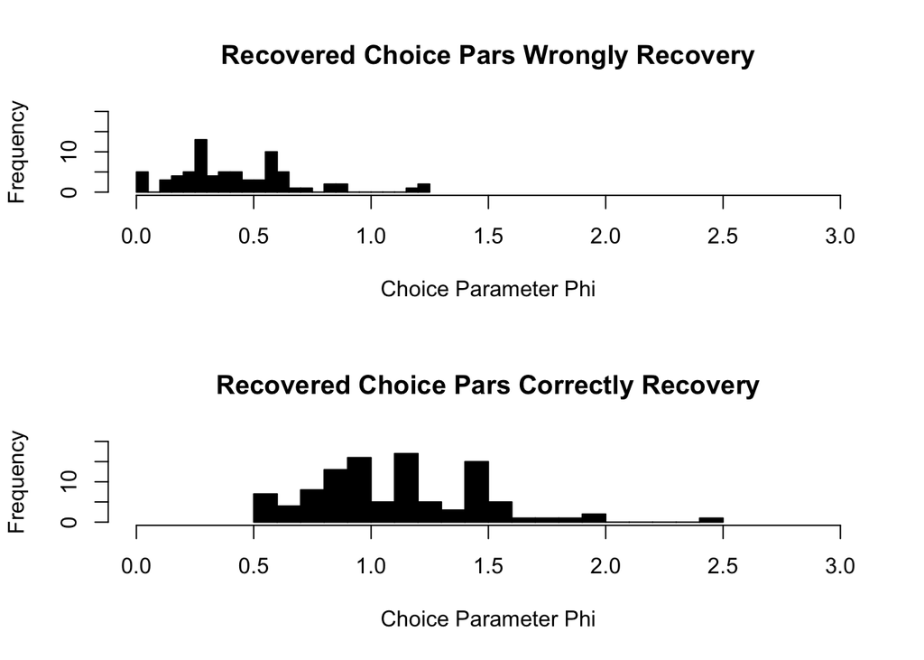

So for the choice parameter $\phi$ the ones with relatively low parameter values were recovered wrongly. Let’s check how the recovered parameters relate to the true ones.

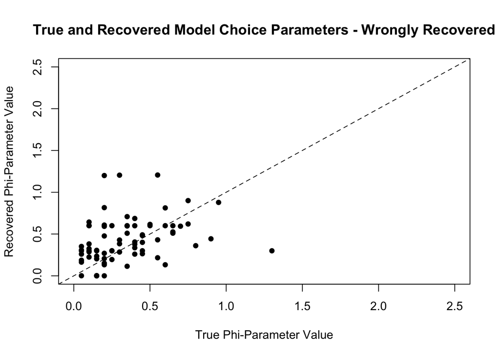

So for the wrongly recovered models the recovered parameter values don’t seem to be much related with the true parameter values with which the data was created. Let’s check the same relationship for the correctly recovered models.

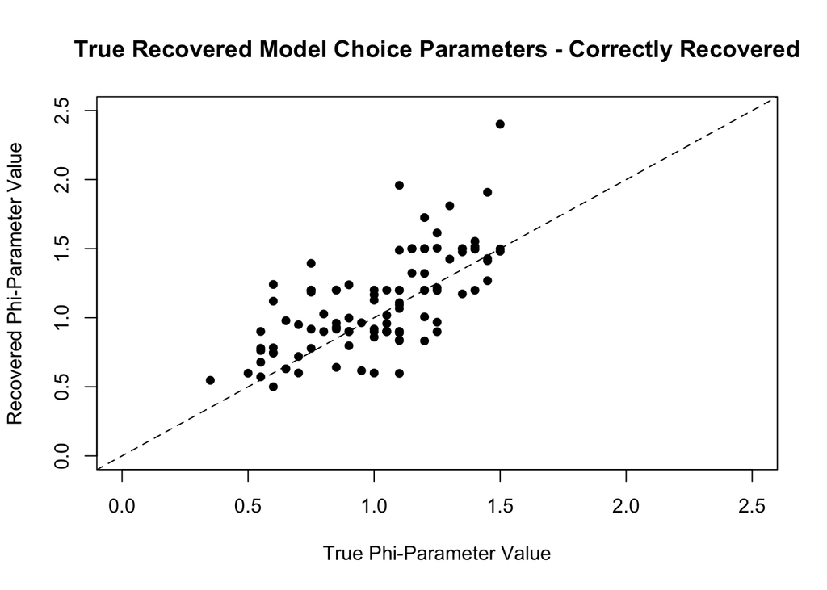

Ok here we have a stronger relationship. Maybe it would be a good idea to check an $\epsilon$-greedy choice rule that we don’t multiply numbers that are close to 0 with each other. So just for comparison, let’s also look at the plot for the $\phi$ parameter of the reinforcement learning model:

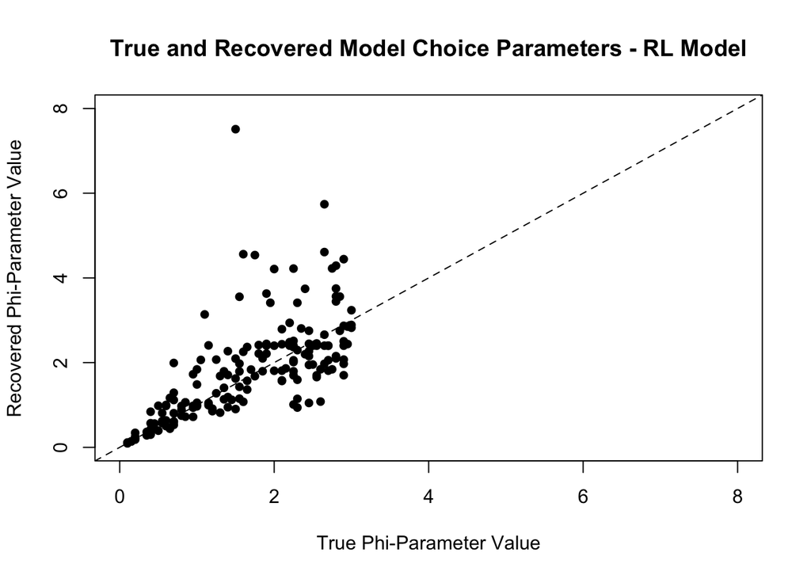

Here parameter values seem to be recovered relatively well. There exists an obvious difference in the choice parameter values of the correctly and incorrectly recovered data generated by the Sample Extrapolation model. So let’s look at the impression parameter, that is, how many samples are drawn from the memory to form a judgement.

First let’s check the histograms of the impression parameters of the wrongly recovered models and the correctly recovered models.

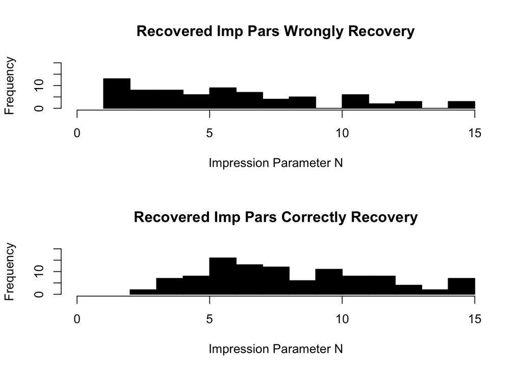

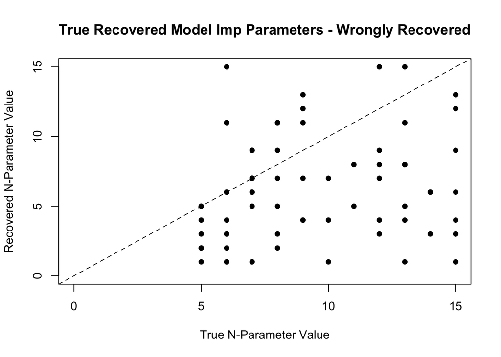

So in the wrongly recovered models, the impression parameter $N$ is often underestimated and there doesn’t seem to be much of a relationship.

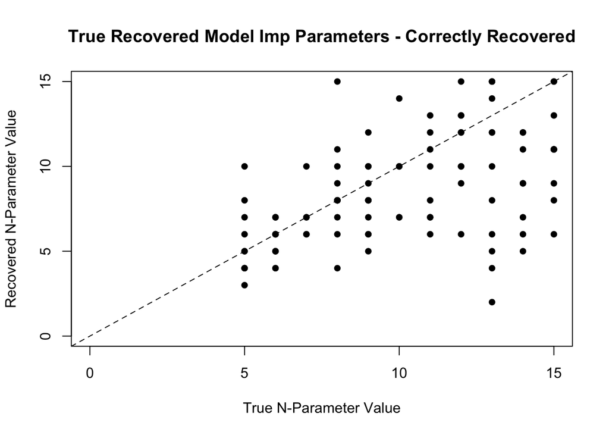

Here it looks much more reasonable. But it seems as if the SampEx model, at least in the current form, needs a relatively high impression parameter, to be correctly recovered. As a comparison, let’s look at the impression parameters from the reinforcement learning model.

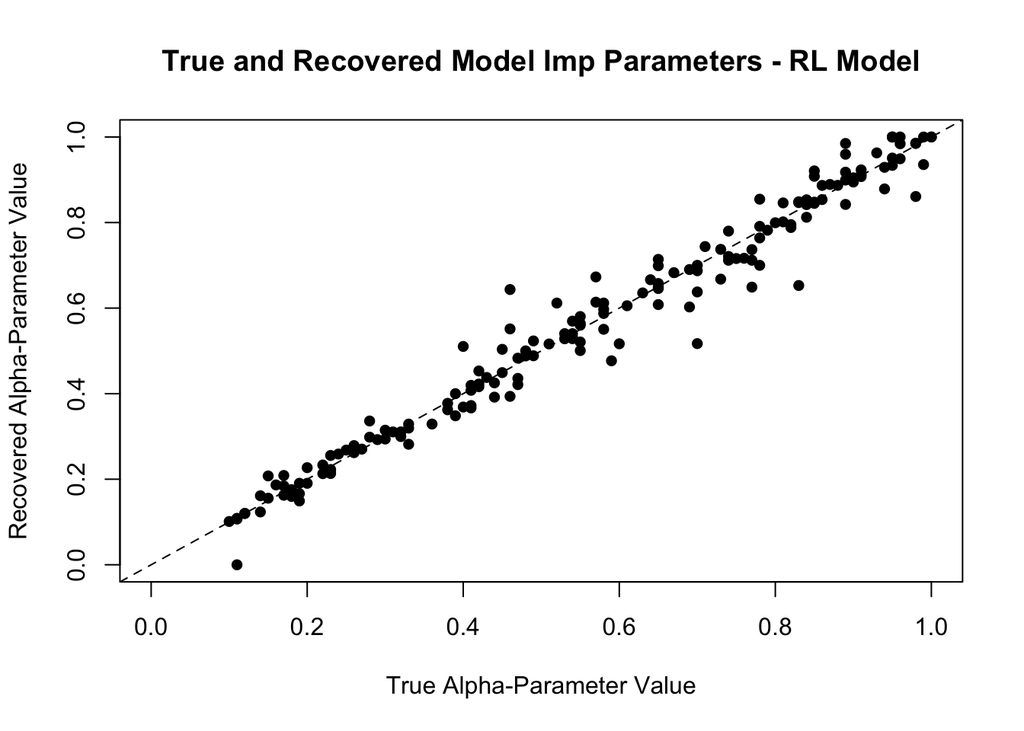

So this is how it is supposed to look. So the SampEx model definitely needs to be revised.

Now lets check the correlation of the parameters for the wrongly recovered model.

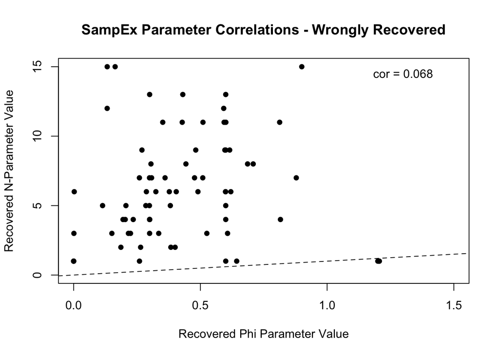

Ok so parameters in the wrongly recovered model are not correlated. Let’s see how this looks for the correctly recovered model.

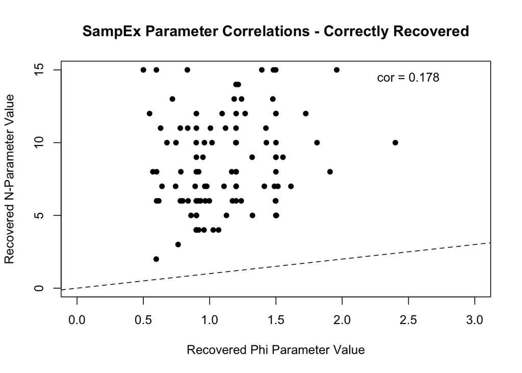

Here the correlation is a bit higher but still not a huge correlation.